# Stat 301-1 Final Project: The EDA Draft

Final Project  
Data Science 1 with R (STAT 301-1)

Author

Daniel Rutstein

Published

December 11, 2024

**Github Repo Link**

[Daniel Rutstein Final Projet Repo Link](https://github.com/danielrutstein/stat-301-1-final-project.git)

[NFL Draft Databse Link](https://docs.google.com/spreadsheets/d/1ERY9mJLI0LpalHmZC6ImHCE6_MhL2_Ic/edit?usp=share_link&ouid=109507493783401190116&rtpof=true&sd=true)

[NFL Draft Prospect Profile Databse Link](https://www.kaggle.com/datasets/jacklichtenstein/espn-nfl-draft-prospect-data/data)

[NFL Coaches Databse Link](https://docs.google.com/spreadsheets/d/18UZee498CfwnV6H5TyBSwKJkd4vGTYiT/edit?usp=sharing&ouid=109507493783401190116&rtpof=true&sd=true)

“all databases also in data folder of GitHub Repo”

**Note**

Reminder of original database: This is the link to my main database, which is a compilation of 10 NFL Draft Classes[^1] from 2011-2020, sourced from Sports Reference’s football website: Pro Football Reference.[^2] Pro Football Reference does not have a feature to download draft classes across years, so I copied and pasted each draft table into an excel spreadsheet (.xlsx), adding a `year` variable to distinguish which draft each observation was from and left the other observations unchanged. There are 29 variables and 2544 observations among the 10 draft classes in this file. [Source: Sports Reference](https://www.pro-football-reference.com/years/2020/draft.htm)

<sup>2</sup> “2011-2020 NFL Draft Listing.” Sports Reference. Accessed November 3, 2024. https://www.pro-football-reference.com/years/2020/draft.htm.

<sup>1</sup> The NFL draft is an event that occurs every year after the football season ends to decide which team college (or in rare cases, international) players ready to turn professional will play for. Each team takes approximately 8 turns to pick players, in ascending order of team wins from the previous season (worst team goes first in each round), although teams are free to trade their draft picks to other teams for veteran players and/or other draft picks. The “draft class” is the group of drafted players in a given year, usually logged with the team and order in the selection process they were drafted.

# Summary

**1) Building the Draft Class: Setting up the `draft` database**

**2) Pre-Draft Scouting: A Univariate Analysis of the NFL Draft**

**3) The EDA Draft: A 7-Round Multivariate Analysis of the NFL Draft**

**Round 1: The Main Event**  
*Does drafting well actually matter?*

**Round 2: Age Takes the Stage**  
*What patterns can we find with player age when drafted and performance?*

**Round 3: Tall Task**  
*Are there biases with height and weight, or are they uncorrelated?*

**Round 4: Coaching Correlations**  
*How does draft pick success relate to NFL Head Coach regime success/failure?*

**Round 5: Hometown Heroes**  
*Are “hometown” picks (when team drafts from nearby colleges) more likely than others? More successful than others?*

**Round 6: Alma Mater Analysis**  
*What is the relationship between college conference/other college groupings and draft pick success rate?)*

**Round 7: Who the Heck Is Mel Kiper?**  
*How do draft picks that deviate from media “consensus” behave when they are either a “reach” (against media consensus) or a “steal” (agree with media consensus?*

## Building the Draft Class: Setting up the `draft` database

### Adding Complexity to Dataset

After submitting progress memo #1, my greatest concern was not having enough “meat on the bone”, per sé, to perform a complex enough EDA. Thus, I found two new datasets to join to my original draft profiles, adding 21 new variables to work with.

The first database was sourced from Kaggle,[^3] containing ESPN.com draft data for each prospect. I am curious how the media performs relative to NFL professionals, so the ESPN position and overall rankings will be nteresting variables to explore. In addition, this database contains information on player height, weight, and whether the draft pick was traded, which gives further opprotunity to explore new research questions. The second database is a summary of NFL coaches by team from 2011-2020, sourced from Sports Reference in an excel spreadsheet I compiled just like my original dataset.[^4] This dataset not only allows for us to see which coaches are most successful at draft picks, how draft pick success relates to turnover (number of coaches per team over the decade), but also contains inofrmation on wins and losses, playoff success, and Super Bowl wins that will be tremendously useful in exploring relationships between draft success and team success.

<sup>3</sup> Lichtenstein, Jack. “ESPN NFL Draft Prospect Data.” Kaggle, May 5, 2021. https://www.kaggle.com/datasets/jacklichtenstein/espn-nfl-draft-prospect-data/data.

<sup>4</sup> “2020 NFL Coaches.” Pro Football Reference. Accessed November 26, 2024. https://www.pro-football-reference.com/years/2020/coaches.htm.

## Pre-Draft Scouting: A Univariate Analysis of the NFL Draft

### Finding the Base Variable

To lay the foundation of my EDA, I need to answer a simple yet ambiguous question: for the purposes of the project, which variable best approximates player success? The two candidates are `w_av`, which is Football Reference’s weighted career value for each player in the dataset across position, and `dr_av`, which uses the same formula, but omits any accumulated career value after leaving the team that drafted them. The pros of each are

`dr_av`: Theoretically, we want to know how valuable a draft pick was to the team that drafted them. Since a team does not care how a player performs for other teams after the player is no longer on their team, `dr_av` succeeds at ignoring this marginal performance.

`w_av`: Just because draft value is a more direct estimator of expected value to the team that drafted them, it is not necessarily the best. There is great variance to consider regarding how a player leaves a team. In a worst case, we have a Type II error where a player gets cut from the team that drafted them, then “breaks out” on another team that takes them on. However, even in this case, it may be the coaching staff’s fault for failing to recognize the talent their personnel staff provided for them, or failure to wait for the learning curve of the player with the 53-man roster constraint in the NFL. Furthermore, there are cases where the player is traded (and the team gets undetected value in the form of trade compensation), or the team is outbid on a second contract, even though they would have liked to retain the player in the absence of free agency.

Thus, I believe `w_av` is a better estimator. Let’s see who the Top 10 players are in `w_av` to confirm our hypothesis.

Top 10 players by w_av

| player | w_av |
| --- | --- |
| Russell Wilson | 136 |
| Aaron Donald | 124 |
| Bobby Wagner | 121 |
| Cam Newton | 115 |
| J.J. Watt | 110 |
| Von Miller | 104 |
| Patrick Peterson | 103 |
| Cameron Jordan | 103 |
| Zack Martin | 102 |
| Jason Kelce | 102 |

For anyone familiar with the NFL, the problem is obvious. Let’s add year to the table.

Top 10 players by w_av

| player | year | w_av |
| --- | --- | --- |
| Russell Wilson | 2012 | 136 |
| Aaron Donald | 2014 | 124 |
| Bobby Wagner | 2012 | 121 |
| Cam Newton | 2011 | 115 |
| J.J. Watt | 2011 | 110 |
| Von Miller | 2011 | 104 |
| Patrick Peterson | 2011 | 103 |
| Cameron Jordan | 2011 | 103 |
| Zack Martin | 2014 | 102 |
| Jason Kelce | 2011 | 102 |

w_av is a cumulative statistic, so there is a heavy bias to players drafted on the earlier half of the 2010’s decade. We could do an average `w_av` by years active to remedy this, but I would argue that would overweigh the converse, as player performance generally regresses with age. Let’s compare how expected value changes by draft year.

summary stats by draft class

[output not shown]

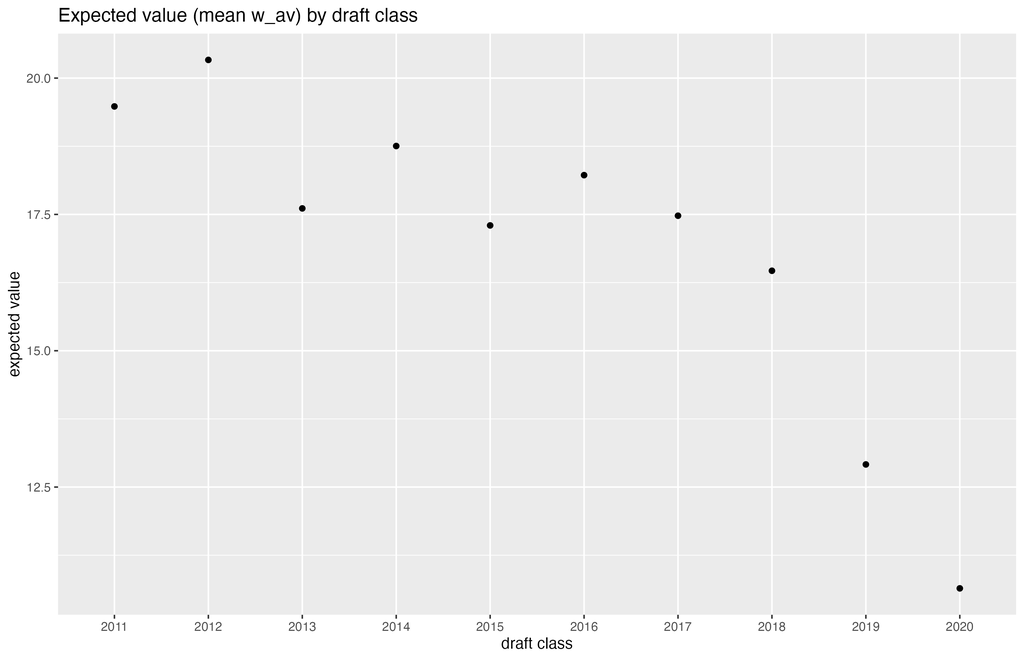

Figure 1: Expected value (mean w_av) by draft class

From Figure 1, looks like a logarithmic regression to me. Let’s normalize our w_av variable by an exponential approximation to minimize the affect of year possible as much as we can.

Top 10 players by log-adjusted w_av

| player | year | rel_w_av |
| --- | --- | --- |
| Russell Wilson | 2012 | 7.485780 |
| Aaron Donald | 2014 | 7.299307 |
| Bobby Wagner | 2012 | 6.660142 |
| Patrick Mahomes | 2017 | 6.539622 |
| Cam Newton | 2011 | 6.154418 |
| Lamar Jackson | 2018 | 6.139371 |
| Josh Allen | 2018 | 6.066283 |
| Zack Martin | 2014 | 6.004269 |
| J.J. Watt | 2011 | 5.886834 |
| Dak Prescott | 2016 | 5.854396 |

The years appear to be more randomly distributed, so the model seems to fit expected value. We could also divide by mean, but this assumes that expected/average draft class value is the same across every year, which is not necessarily true (there is variance in the strength of each draft class). In conclusion, therefore, `rel_w_av` will be considered our main variable to estimate success of a draft pick in this exploration.

### Cleaning/Adding Helpful Variables

Added integer `career_length` and boolean `active` variables to easily recall how long a player played (or has played) in the NFL and whether they are still playing.

Created `pos_group` variable to condense positions into the groups that the NFL talent evaluation community typically uses to bucket players. This makes digesting factor variables much easier, as this cuts our levels from 22 to 10.

### Analysis of rel_w_av

Viewing the density plot of `rel_w_av` (see Figure 2) and the boxplot of `rel_w_av` by `round` (see Figure 3), the data behaves as we expect. Only 50.7% of players are “starters” for at least one NFL season, and only 22.9% are “starters: for at least 4 years (the duration of an NFL contract). Thus, it makes sense that the density of `rel_w_av` skews heavily to the right, since the near median draft pick does not even start for any season in the NFL. The long tail also makes sense since star players (Russell Wilson, Aaron Donald, Patrick Mahomes), return substantially more value to their teams over their careers than the average player. Grouping `rel_w_av` by round in Figure 3, the pattern also follows exactly what would be expected: each quartile and the median always decreases as round increases. The soundness of `rel_w_av` in conforming to expected patterns supports the notion that `rel_w_av` is a fairly accurate estimator of success of a draft pick.

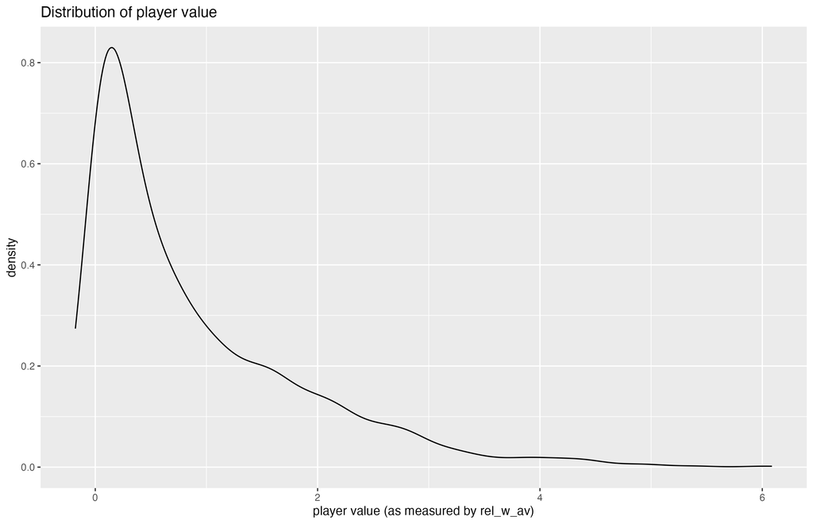

Figure 2: Distribution of player value

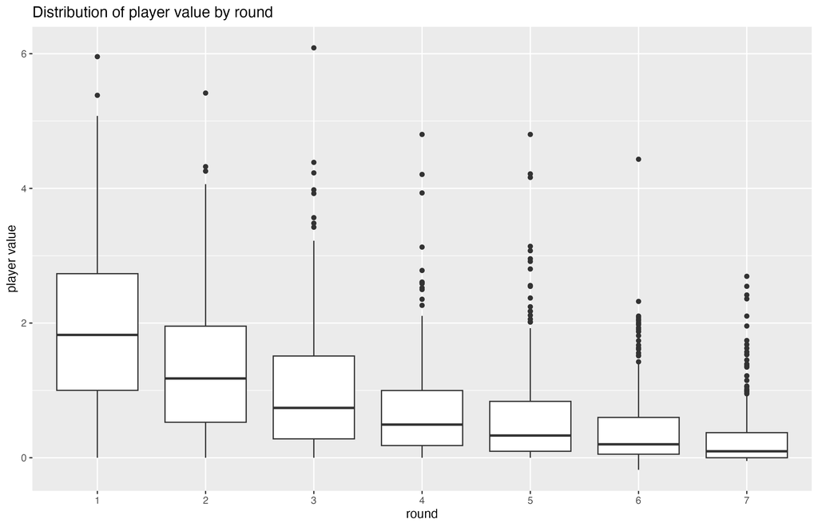

Figure 3: Distribution of player value by round

### Analysis of pos_group

An important factor variable to consider in the exploration is position group (`pos_group` in tibble). Although `rel_w_av` attempts to determine how valuable a player is independent of position, each player in football performs a completely different role (unlike, say, baseball) and is evaluated on completely different criteria.

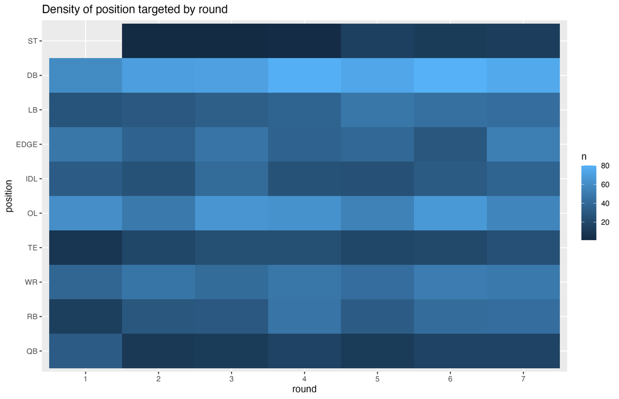

Figure 4: Density of position targeted by round

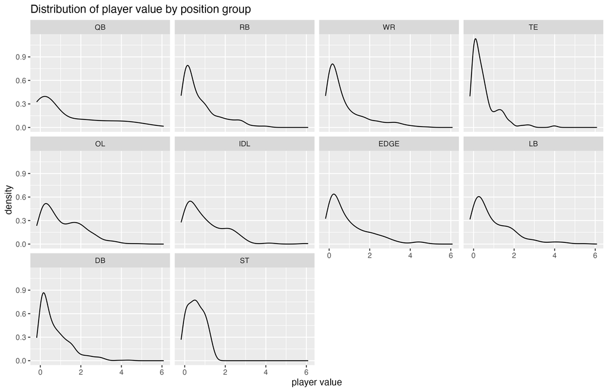

Figure 5: Density of player value by position group

From Figure 5, we can clearly see the distribution of expected value by `pos_group` is not uniform. Tight ends and defensive backs have an especially high density near 0, whereas offensive lineman and quarterbacks are less dense in this region, meaning they are less likely to outright fail.

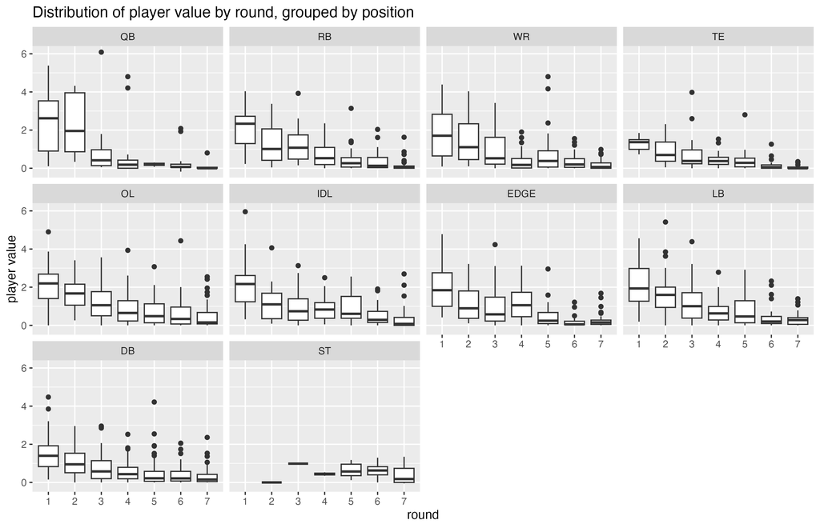

Figure 6: Density of player value by round, grouped by position

Furthermore, Figure 6 demonstrates that dropoffs in value by round differ by `pos_group`. For example, there is a sharp dropoff in value after the first two rounds for quarterbacks, whereas offensive linemen and defensive backs follow a steady linear decline in value.

## The EDA Draft

### Round 1: The Main Event

**Does drafting well actually matter?**

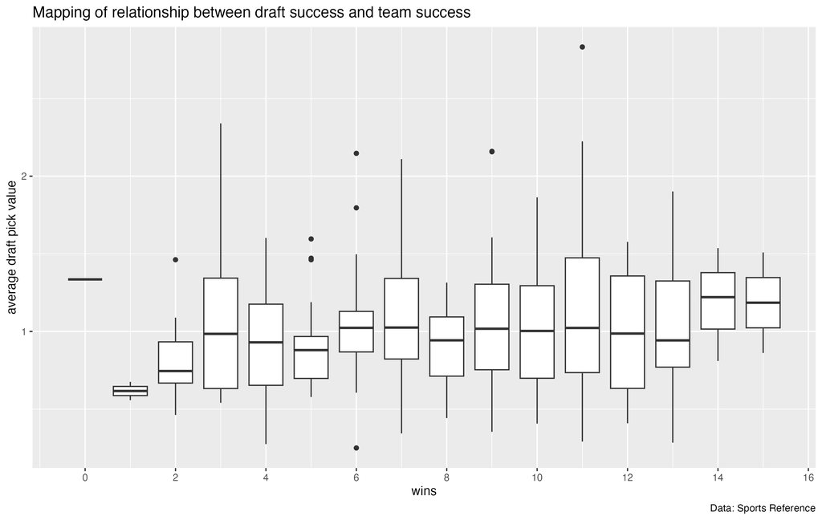

Figure 7: Mapping of Relationship between draft success and team success

### Round 2: Age Takes the Stage

**What patterns can we find with player age when drafted and performance?**

### Round 3: Tall Task

**Are there biases with height and weight, or are they uncorrelated?**

### Round 4: Coaching Correlations

**How does draft pick success relate to NFL Head Coach regime success/failure?**

### Round 5: Hometown Heroes

**Are “hometown” picks (when team drafts from nearby colleges) more likely than others? More successful than others?**

### Round 6: Alma Mater Analysis

**What is the relationship between college conference/other college groupings and draft pick success rate?**

### *Round 7: Who the H*** Is Mel Kiper?*

**How do draft picks that deviate from media “consensus” behave when they are either a “reach” (against media consensus) or a “steal” (agree with media consensus)?**